[figure not shown]

# Tabular data - Bivariate relationships III: Categorical-Numerical

1. Exploring the data
2. Common plots
3. Complex and custom plots

Let me use again the data about crime from the Seattle Open Data portal:

```r
rm(list = ls())

# collecting the data
link="https://github.com/DACSS-Visual/tabular_bivar_catcat/raw/main/data/crime.RData"
load(file = url(link))
```

The data available are:

```r
# variables in the data:
names(crime)
```

```
##  [1] "Report.Number"               "Occurred.Date"
##  [3] "year"                        "month"
##  [5] "weekday"                     "Occurred.Time"
##  [7] "Occurred.DayTime"            "Reported.Date"
##  [9] "Reported.Time"               "DaysToReport"
## [11] "crimecat"                    "Crime.Subcategory"
## [13] "Primary.Offense.Description" "Precinct"
## [15] "Sector"                      "Beat"
## [17] "Neighborhood"
```

The *data types* recognised in R are:

```r
str(crime,width = 70,strict.width='cut')
```

```
## 'data.frame':    499698 obs. of  17 variables:
##  $ Report.Number              : chr  "20130000244104" "201300002429"..
##  $ Occurred.Date              : Date, format: "2013-07-09" ...
##  $ year                       : num  2013 2013 2013 2013 2013 ...
##  $ month                      : num  7 7 7 7 7 7 7 7 7 7 ...
##  $ weekday                    : Ord.factor w/ 7 levels "Monday"<"Tu"..
##  $ Occurred.Time              : num  1930 1917 1900 1900 1846 ...
##  $ Occurred.DayTime           : Ord.factor w/ 4 levels "day"<"after"..
##  $ Reported.Date              : Date, format: "2013-07-10" ...
##  $ Reported.Time              : num  1722 2052 35 1258 1846 ...
##  $ DaysToReport               : num  1 0 1 1 0 0 0 0 1 0 ...
##  $ crimecat                   : Factor w/ 20 levels "AGGRAVATED ASS"..
##  $ Crime.Subcategory          : Factor w/ 30 levels "AGGRAVATED ASS"..
##  $ Primary.Offense.Description: Factor w/ 144 levels "ADULT-VULNERA"..
##  $ Precinct                   : Factor w/ 5 levels "EAST","NORTH",....
##  $ Sector                     : Factor w/ 23 levels "6804","9512",....
##  $ Beat                       : Factor w/ 64 levels "B1","B2","B3",...
##  $ Neighborhood               : Factor w/ 58 levels "ALASKA JUNCTIO"..
```

The data is from several years:

```r
summary(crime$year)
```

```
##    Min. 1st Qu.  Median    Mean 3rd Qu.    Max.    NA's
##    1908    2010    2013    2013    2016    2018       2
```

Let’s keep some years:

```r
yearsSelected=2011:2015

subCrime=crime[crime$year%in%yearsSelected,]

#let's keep complete data

subCrime=subCrime[complete.cases(subCrime),]
```

Go to table of contents.

## Exploring the data

The goal is to find a visualization to represent the *behavior of a numerical variable* in *each level* of a categorical variable. Let’s choose one of each and see the descriptives:

```r
tapply(subCrime$DaysToReport,subCrime$Precinct, summary)
```

```
## $EAST
##    Min. 1st Qu.  Median    Mean 3rd Qu.    Max.
##     0.0     0.0     0.0     4.9     1.0  2303.0
##
## $NORTH
##     Min.  1st Qu.   Median     Mean  3rd Qu.     Max.
##    0.000    0.000    0.000    5.077    1.000 2558.000
##
## $SOUTH
##     Min.  1st Qu.   Median     Mean  3rd Qu.     Max.
##    0.000    0.000    0.000    4.047    1.000 2075.000
##
## $SOUTHWEST
##     Min.  1st Qu.   Median     Mean  3rd Qu.     Max.
##    0.000    0.000    0.000    6.217    1.000 2524.000
##
## $WEST
##     Min.  1st Qu.   Median     Mean  3rd Qu.     Max.
##    0.000    0.000    0.000    3.846    1.000 2593.000
```

As there seems to be lots of asymmetry, let’s explore with boxplots several lengths using **ggarrange** from *ggpubr*:

```r
library(ggpubr)
```

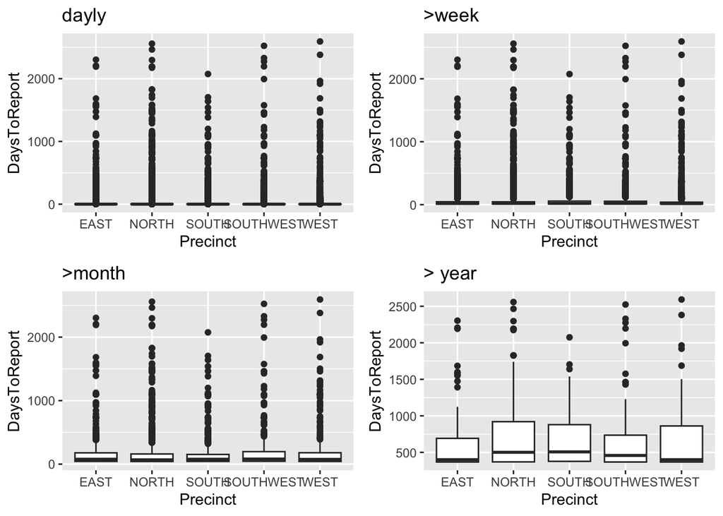

```r
baseDay=ggplot(data=subCrime,
            aes(x=Precinct,y=DaysToReport))
boxDay=baseDay + geom_boxplot() + labs(title = "dayly")

baseWeek=ggplot(data=subCrime[subCrime$DaysToReport>7,],
            aes(x=Precinct,y=DaysToReport))
boxWeek=baseWeek + geom_boxplot() + labs(title = ">week")

baseMonth=ggplot(data=subCrime[subCrime$DaysToReport>30,],
            aes(x=Precinct,y=DaysToReport))
boxMonth=baseMonth + geom_boxplot() + labs(title = ">month")


baseYear=ggplot(data=subCrime[subCrime$DaysToReport>365,],
            aes(x=Precinct,y=DaysToReport))
boxYear=baseYear + geom_boxplot() + labs(title = "> year")



#all in one:
ggarrange(boxDay,boxWeek,boxMonth,boxYear)
```

Let’s build our visual from the crimes that took ONE year or longer to report.

```r
crimePrecinct=subCrime[subCrime$DaysToReport>=365,]
crimePrecinct$yearsToReport=crimePrecinct$DaysToReport/365
```

In general, we want to see if the distribution is different across levels:

```r
kruskal.test(yearsToReport~Precinct,data=crimePrecinct)
```

```
##
##  Kruskal-Wallis rank sum test
##
## data:  yearsToReport by Precinct
## Kruskal-Wallis chi-squared = 9.1454, df = 4, p-value = 0.05757
```

We find borderline evidence of precinct-level differences (p = 0.058 falls just above the conventional 0.05 threshold). Let’s explore which pairs may be driving this pattern:

```r
pairwise.wilcox.test(crimePrecinct$yearsToReport,crimePrecinct$Precinct)
```

```
##
##  Pairwise comparisons using Wilcoxon rank sum test with continuity correction
##
## data:  crimePrecinct$yearsToReport and crimePrecinct$Precinct
##
##           EAST NORTH SOUTH SOUTHWEST
## NORTH     0.20 -     -     -
## SOUTH     0.71 1.00  -     -
## SOUTHWEST 1.00 1.00  1.00  -
## WEST      1.00 0.14  0.81  1.00
##
## P value adjustment method: holm
```

Arguably, EAST might differ from NORTH; and WEST from NORTH. What plot may help us show that?

Go to table of contents.

## Common plots for differences

Let’s redo the boxplot and histograms:

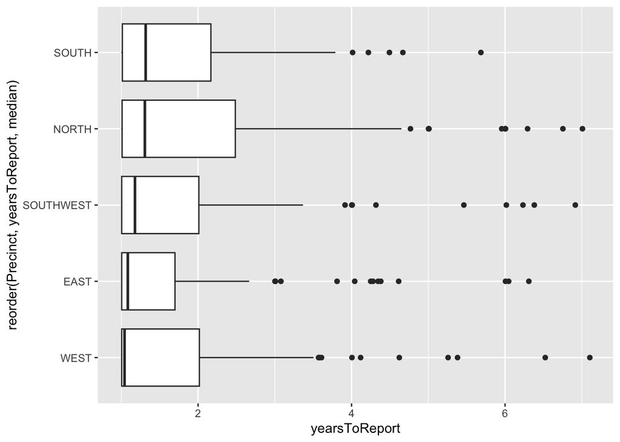

```r
library(ggplot2)
baseBox=ggplot(data=crimePrecinct,
            aes(y=yearsToReport))

baseBox + geom_boxplot(aes(x=reorder(Precinct,yearsToReport,median))) +
    coord_flip()
```

Density plots?

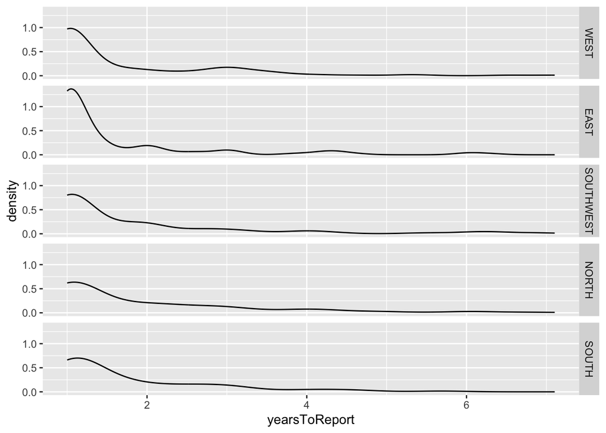

```r
ggplot(crimePrecinct) + geom_density(aes(x = yearsToReport),show.legend = F) + facet_grid(reorder(Precinct,yearsToReport,median)~.)
```

Or the histogram:

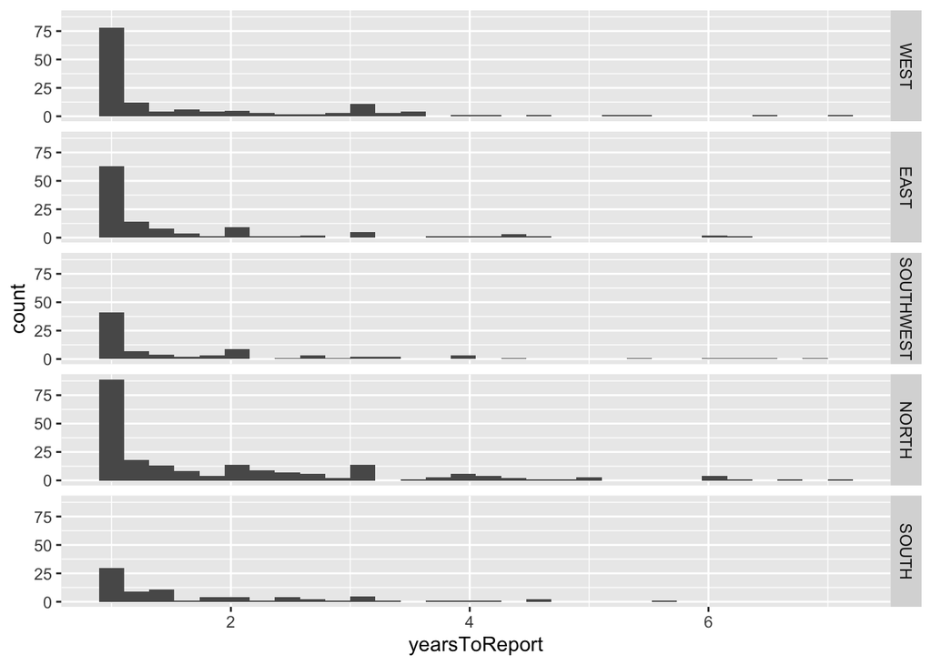

```r
baseHist=ggplot(data=crimePrecinct,
            aes(x=yearsToReport))

baseHist + geom_histogram() +facet_grid(reorder(Precinct,yearsToReport,median)~.)
```

The boxplot helps more with positional values (quartiles) and outliers; but due to the skewness neither the histograms nor the density plot add much insight.

Skewness can be hidden, which is wrong, with common visuals as the mean-error plot, which shows the mean of the numeric variable including a confidence interval. Let me first show the mean of *yearsToReport* per *Precinct*:

```
## No summary function supplied, defaulting to `mean_se()`
```

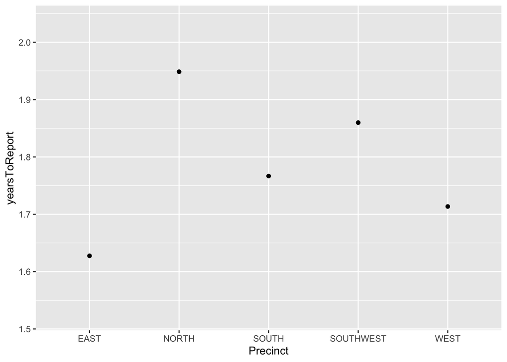

```r
baseMEANs=ggplot(crimePrecinct, aes(x=Precinct,
                             y=yearsToReport))
pointMEANS=baseMEANs + geom_point(stat="summary")
pointMEANS
```

Now, we can add now the error bar:

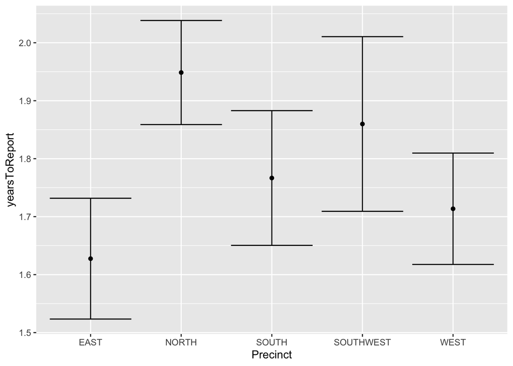

```r
ErrorPlot=pointMEANS + geom_errorbar(stat="summary")
ErrorPlot
```

Error bars give you the illusion of symmetry; so, consider including the data in the plot:

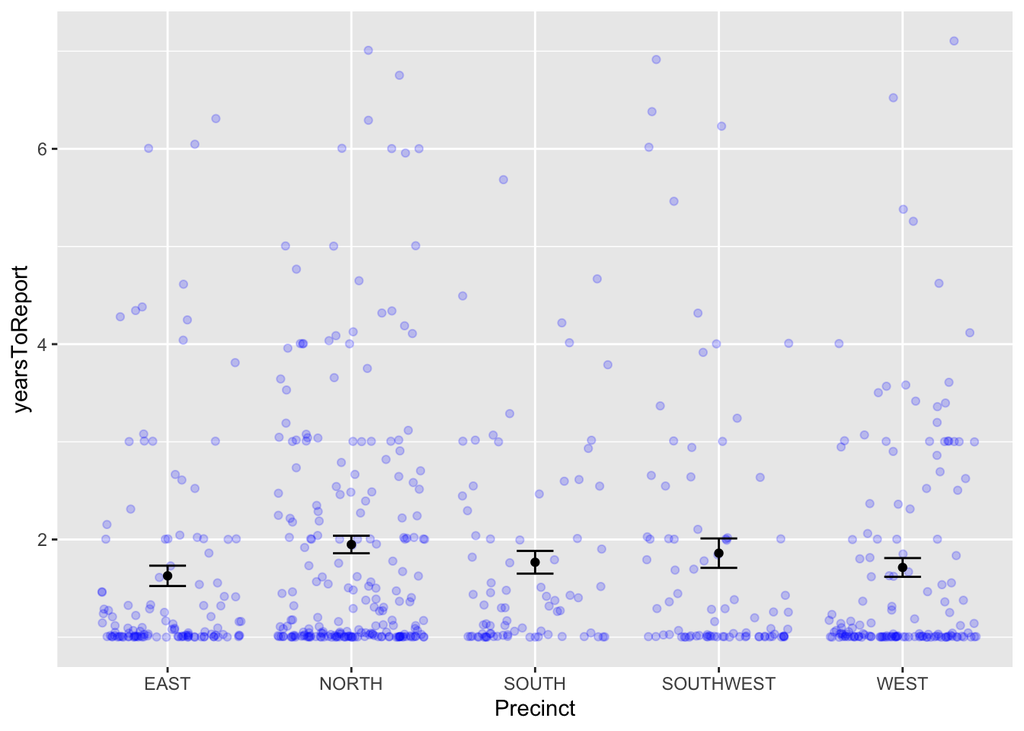

```r
baseMEANs= ggplot(crimePrecinct, aes(x=Precinct,
                      y=yearsToReport))
jitterMEANs= baseMEANs + geom_jitter(colour="blue",
                             alpha=0.2 #transparency
                             )
jitterMEANs=jitterMEANs + geom_point(stat="summary") +
             geom_errorbar(stat="summary",width=.2)
jitterMEANs
```

The task is to reveal these:

```r
tapply(crimePrecinct$yearsToReport,crimePrecinct$Precinct, summary)
```

```
## $EAST
##    Min. 1st Qu.  Median    Mean 3rd Qu.    Max.
##   1.000   1.005   1.085   1.628   1.699   6.310
##
## $NORTH
##    Min. 1st Qu.  Median    Mean 3rd Qu.    Max.
##   1.000   1.010   1.307   1.949   2.486   7.008
##
## $SOUTH
##    Min. 1st Qu.  Median    Mean 3rd Qu.    Max.
##   1.000   1.014   1.318   1.767   2.167   5.685
##
## $SOUTHWEST
##    Min. 1st Qu.  Median    Mean 3rd Qu.    Max.
##   1.000   1.005   1.178   1.860   2.010   6.915
##
## $WEST
##    Min. 1st Qu.  Median    Mean 3rd Qu.    Max.
##   1.000   1.005   1.042   1.714   2.017   7.104
```

Go to table of contents.

## Complex and custom plots

Could the violin plot be the answer?

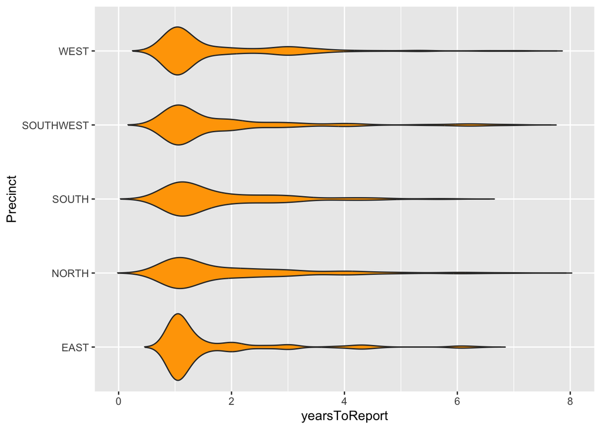

```r
vio=baseBox+geom_violin(aes(x=Precinct), fill="orange",trim = F)
vio + coord_flip()
```

Let’ see if the grid can help represent the stats?

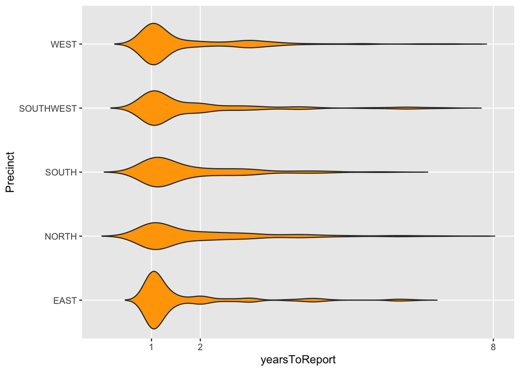

```r
vio2= vio + coord_flip() +
    scale_y_continuous(breaks = c(1,2,8)) +
    theme(panel.grid.minor = element_blank())

vio2
```

It is difficult to annotate cat-num plots, because each plot has different values. Let me compute the *median* and *max* values for one of the violins:

```r
tapply(crimePrecinct$yearsToReport,
       crimePrecinct$Precinct,
       summary)$EAST[c(3,6)]%>%
                            round(3) ->eastMdMx

eastMdMx%>%as.list()%>%as.data.frame() ->eastMdMx_ValuesInDF
names(eastMdMx_ValuesInDF)=c('median','max')
eastMdMx_ValuesInDF
```

```
##   median  max
## 1  1.085 6.31
```

Let me keep the integer part:

```r
trunc(eastMdMx_ValuesInDF)
```

```
##   median max
## 1      1   6
```

Now the decimal part, coverted to months:

```r
trunc(12*eastMdMx_ValuesInDF%%1)
```

```
##   median max
## 1      1   3
```

This could be a simple annotation for this case:

```r
text_eastMdMx_ValuesInDF=paste0(trunc(eastMdMx_ValuesInDF),"y_",
                               trunc(12*eastMdMx_ValuesInDF%%1),'m')
text_eastMdMx_ValuesInDF
```

```
## [1] "1y_1m" "6y_3m"
```

Now, replace the values in *eastMdMx_ValuesInDF*:

```r
eastMdMx_ValuesInDF[1,]=text_eastMdMx_ValuesInDF
eastMdMx_ValuesInDF
```

```
##   median   max
## 1  1y_1m 6y_3m
```

Let’s annotate:

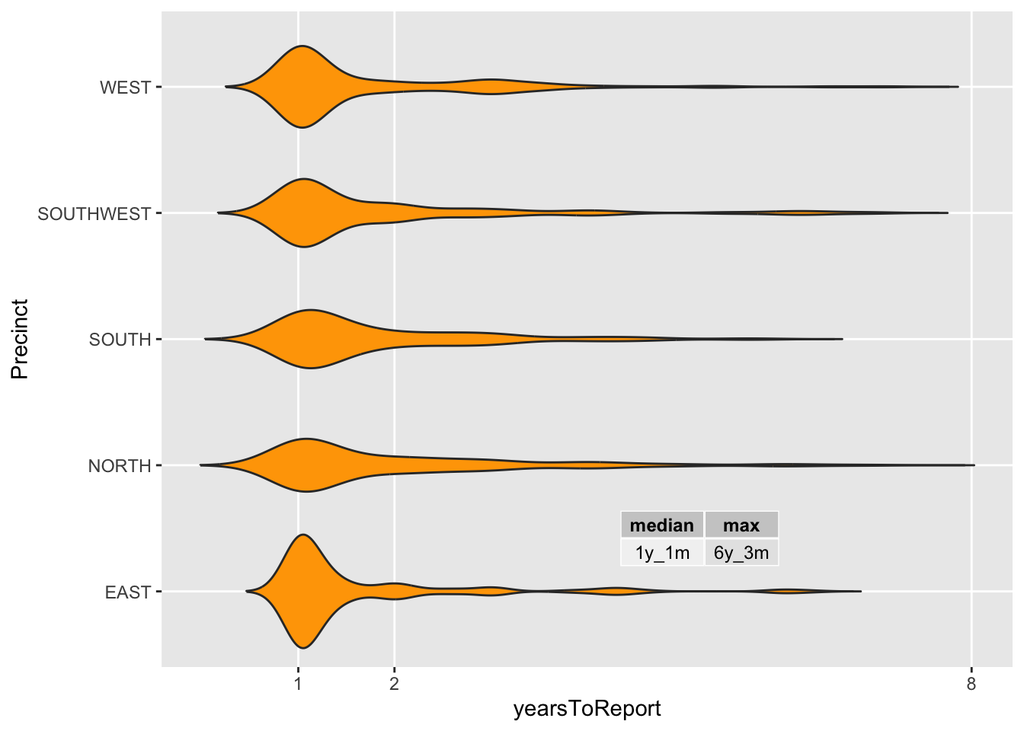

```r
## prepare annotation
library(tibble)
eastT=tibble(x=1.2,y=6,tb=list(eastMdMx_ValuesInDF))

## add a geom_table()
library(ggpmisc)
vio2 + geom_table(data=eastT,
             aes(x = x, y = y, label = tb))
```

We need annotations for each violin. Too much work, unless we create a function:

```r
tableAnnot=function(theValues,posX,posY){
                 output=theValues[c(3,6)]%>%
                         round(3) %>%
                          as.list()%>%
                            as.data.frame()
                 names(output)=c('median','max')
                 text_output=paste0(trunc(output),"y_",
                                    trunc(12*output%%1),'m')
                 output[1,]=text_output

                 tibble(x=posX,y=posY,tb=list(output))
}
```

If we have the summary for a precinct, we have a annotation:

```r
E_input=tapply(crimePrecinct$yearsToReport,
       crimePrecinct$Precinct,
       summary)$EAST

tableAnnot(E_input,1.2,6)
```

```
## # A tibble: 1 × 3
##       x     y tb
##   <dbl> <dbl> <list>
## 1   1.2     6 <df [1 × 2]>
```

Let’s use our function for each case:

```r
N_Input=tapply(crimePrecinct$yearsToReport,
       crimePrecinct$Precinct,
       summary)$NORTH
S_Input=tapply(crimePrecinct$yearsToReport,
       crimePrecinct$Precinct,
       summary)$SOUTH
SW_Input=tapply(crimePrecinct$yearsToReport,
       crimePrecinct$Precinct,
       summary)$SOUTHWEST
W_Input=tapply(crimePrecinct$yearsToReport,
       crimePrecinct$Precinct,
       summary)$WEST


E_FromFun=tableAnnot(E_input,1,8)
N_FromFun=tableAnnot(N_Input,2,8)
S_FromFun=tableAnnot(S_Input,3,8)
SW_FromFun=tableAnnot(SW_Input,4,8)
W_FromFun=tableAnnot(W_Input,5,8)
```

We get:

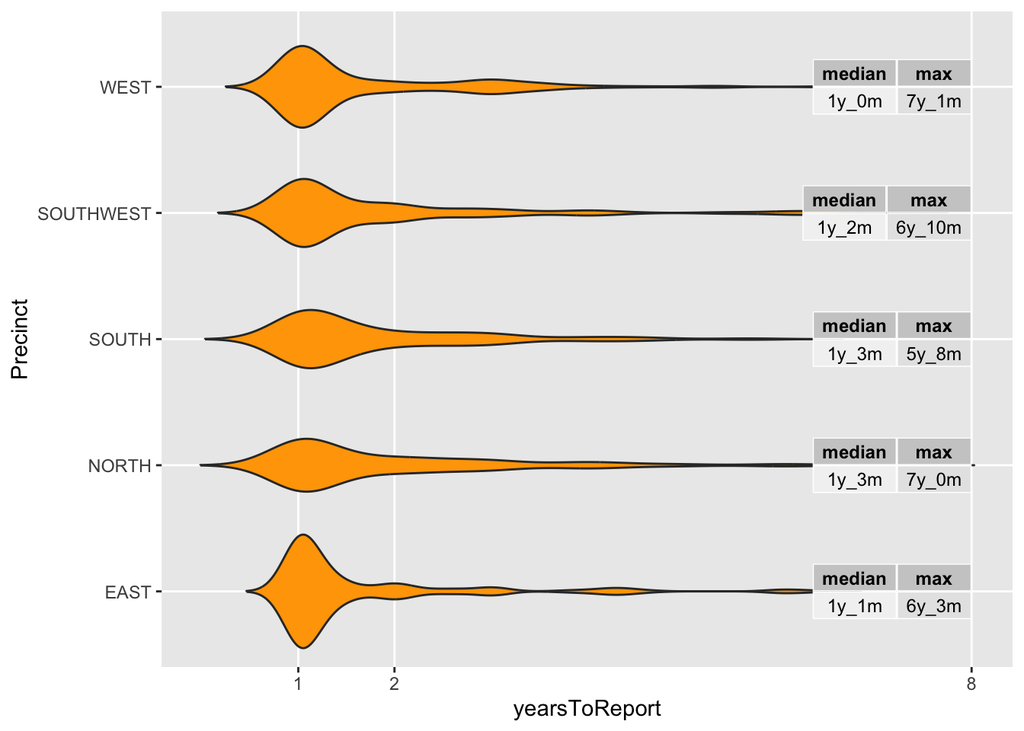

```r
vio2 + geom_table(data=E_FromFun,
             aes(x = x, y = y, label = tb),vjust = 0.5) +
       geom_table(data=N_FromFun,
             aes(x = x, y = y, label = tb),vjust = 0.5) +
       geom_table(data=S_FromFun,
             aes(x = x, y = y, label = tb),vjust = 0.5) +
       geom_table(data=SW_FromFun,
             aes(x = x, y = y, label = tb),vjust = 0.5) +
       geom_table(data=W_FromFun,
             aes(x = x, y = y, label = tb),vjust = 0.5)
```

```r
# would you ever need?
    #scale_y_continuous(trans='log2')
    #scale_y_log10()
```

Remember the violin plot shows **density**, so it looks as though there are values that are not supposed to be:

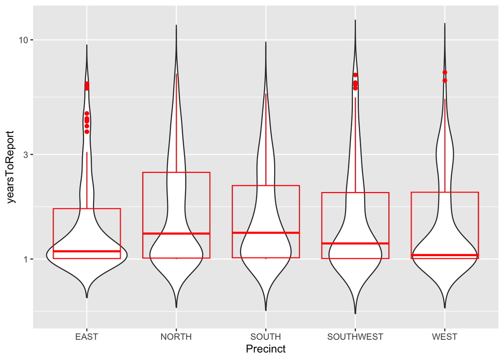

```r
baseBox=ggplot(data=crimePrecinct,
            aes(y=yearsToReport))
baseBox + geom_violin(aes(x=Precinct), fill="white",trim = F) + geom_boxplot(aes(x=Precinct),fill=NA,color='red') + scale_y_log10()
```

The boxplot above does show the values, and as you see the violin shows a density, a continuous distribution. The values are greater than 1, and you see the boxplot starst in one; but the violin plot shows a distributions as there were values lower than 1.

What about values easier to decode in a simpler plot?

Let’s recover the stats:

```r
summaryBy=aggregate(data=crimePrecinct,
                    yearsToReport~Precinct,
                    FUN = function(x) c(median = median(x),
                                        max=max(x)) )
#when several functions at play
summaryBy=do.call(data.frame,summaryBy)
summaryBy
```

```
##    Precinct yearsToReport.median yearsToReport.max
## 1      EAST             1.084932          6.309589
## 2     NORTH             1.306849          7.008219
## 3     SOUTH             1.317808          5.684932
## 4 SOUTHWEST             1.178082          6.915068
## 5      WEST             1.042466          7.104110
```

Let’s change the default names:

```r
names(summaryBy)=c('Precinct','median','max')
summaryBy
```

```
##    Precinct   median      max
## 1      EAST 1.084932 6.309589
## 2     NORTH 1.306849 7.008219
## 3     SOUTH 1.317808 5.684932
## 4 SOUTHWEST 1.178082 6.915068
## 5      WEST 1.042466 7.104110
```

This is a wide format, then:

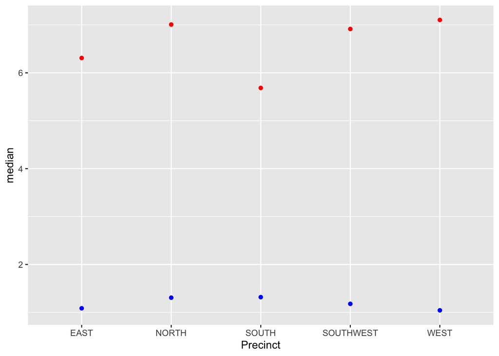

```r
ggplot(data=summaryBy, aes(x=Precinct))  +
  # geom per column
  geom_point(aes(y=median),color='blue') +
       geom_point(aes(y=max),color='red')
```

It is more manageable if we use the long format:

```r
summaryBy_long <- reshape2::melt(summaryBy,
                                  id.vars = "Precinct",
                                  variable.name = "stat",
                                  value.name = "yearsToReport")
summaryBy_long
```

```
##     Precinct   stat yearsToReport
## 1       EAST median      1.084932
## 2      NORTH median      1.306849
## 3      SOUTH median      1.317808
## 4  SOUTHWEST median      1.178082
## 5       WEST median      1.042466
## 6       EAST    max      6.309589
## 7      NORTH    max      7.008219
## 8      SOUTH    max      5.684932
## 9  SOUTHWEST    max      6.915068
## 10      WEST    max      7.104110
```

Now, ‘color’ uses a variable,

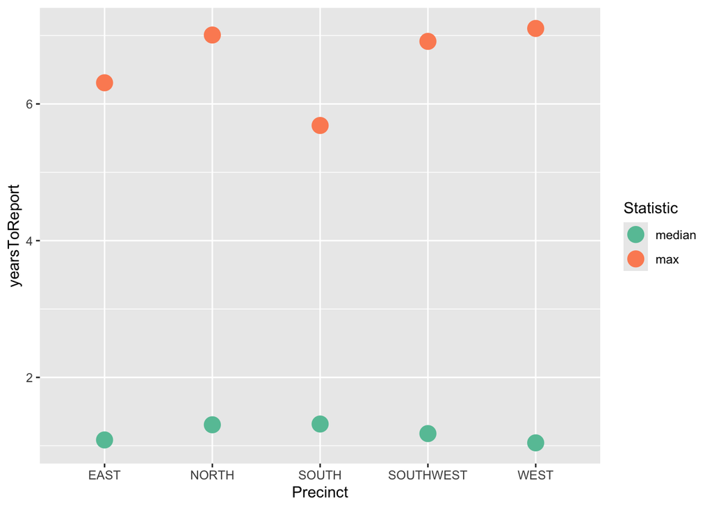

```r
# Then map color aesthetically:
base_summ=ggplot(summaryBy_long)
vars_summ=base_summ+ aes(x = Precinct, y = yearsToReport, color = stat)
geom_summ= vars_summ + geom_point(size = 5)

  # we manage color wihth palettes
geom_summ + scale_color_brewer(palette = "Set2") +
            labs(color = "Statistic")  # Legend title
```

What about bars?

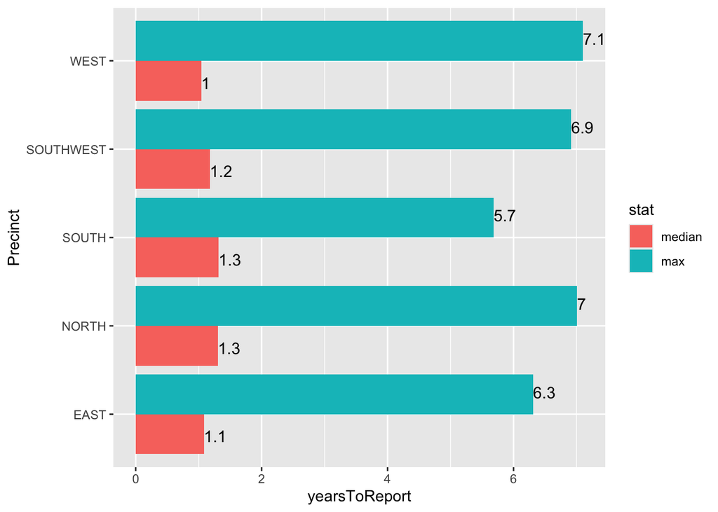

```r
base1=ggplot(data=summaryBy_long,
             aes(x=Precinct, y=yearsToReport,
                 fill=stat)) # fill brings a legend
barDodge= base1 +  geom_bar(stat="identity",
                            position ='dodge')
barDodge + geom_text(size = 4,
                     position = position_dodge(1),hjust=0,
                     aes(label=round(yearsToReport,1)))+
    coord_flip()
```

Thinner bars?

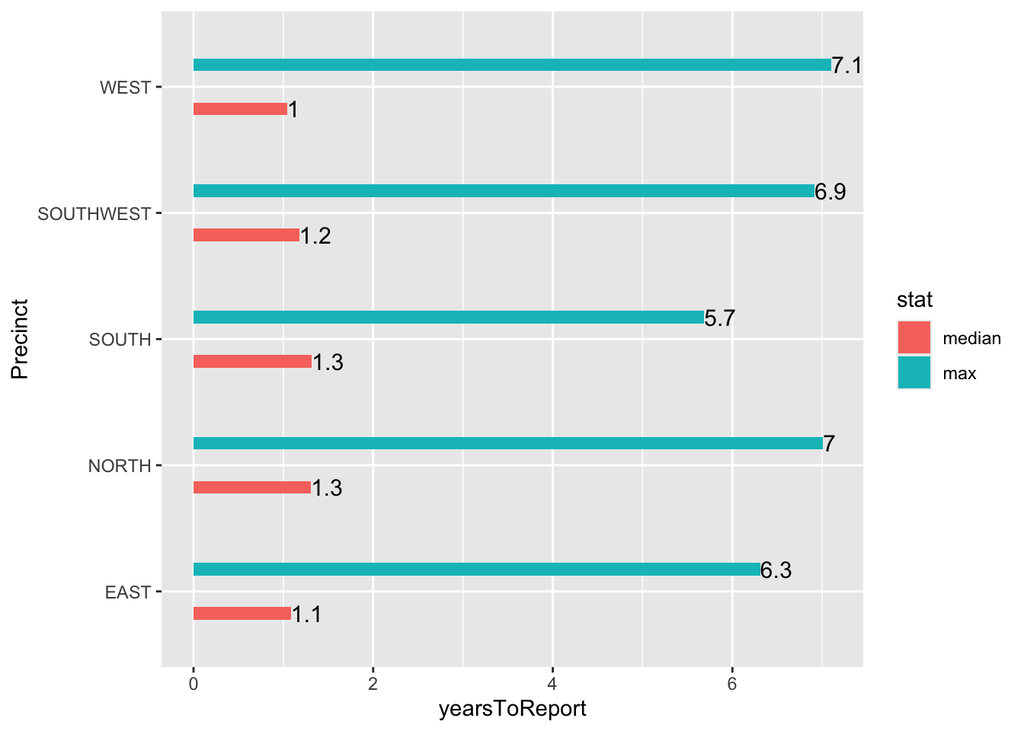

```r
base1=ggplot(data=summaryBy_long,
             aes(x=Precinct, y=yearsToReport,
                 fill=stat))
barDodge= base1 +  geom_bar(stat="identity",
                            position =position_dodge(.7),width = 0.2)
barDodge + geom_text(size = 4,
                     position = position_dodge(0.7),hjust=0,
                     aes(label=round(yearsToReport,1))) +
    coord_flip()
```

The use of facetted bars?

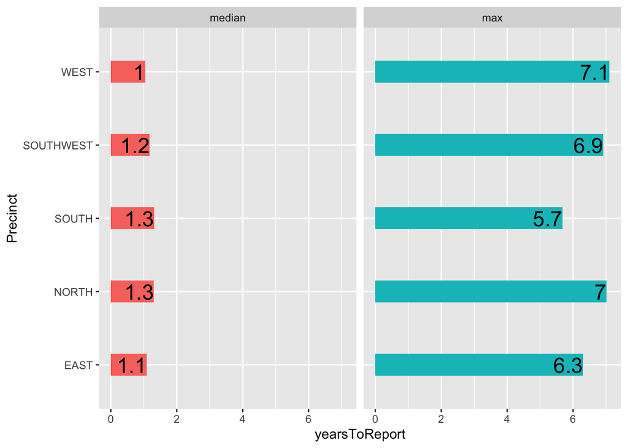

```r
bars=base_summ + geom_bar(aes(x=Precinct,y=yearsToReport,fill=stat),
                     stat = 'identity', width = 0.3,
                     show.legend = F) +
    geom_text(size = 6,
                     position = position_dodge(0.7),hjust=1,
                     aes(x=Precinct,
                         y=yearsToReport,
                         label=round(yearsToReport,1)))

bars + facet_grid(~stat) + coord_flip()
```

…or segments?

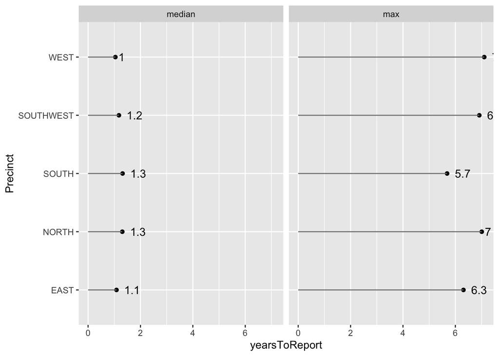

```r
bars=base_summ + geom_point(aes(x=Precinct,y=yearsToReport,fill=stat),
                       stat = 'identity',
                       show.legend = F) +
    geom_text(size = 4,hjust=-0.5,
                     aes(x=Precinct,y=yearsToReport,
                         label=round(yearsToReport,1))) +
    geom_segment(aes(y = 0,
                     x = Precinct,
                     yend = yearsToReport,
                     xend = Precinct),
                 color = "grey50")


bars =bars + facet_grid(~stat) + coord_flip()
bars
```

A better location for the text?

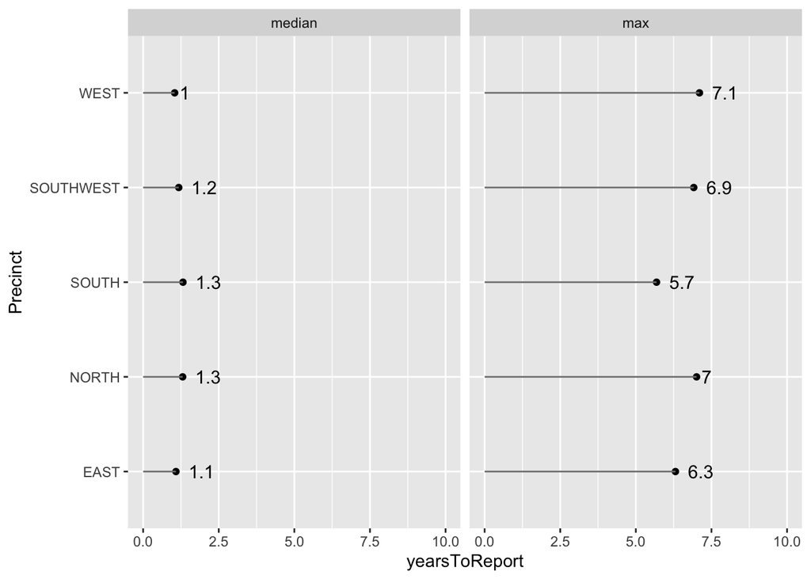

```r
bars + scale_y_continuous(limits = c(0,10))
```

…or

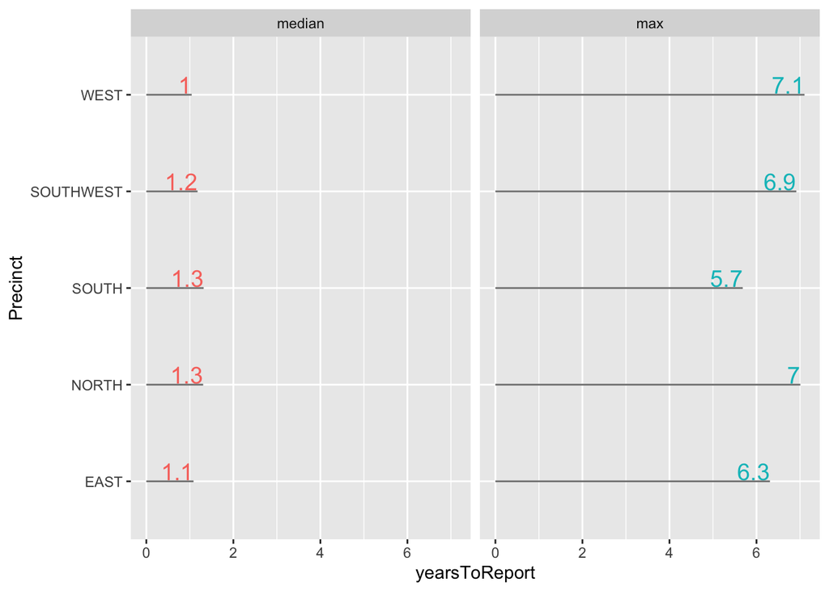

```r
bars=base_summ+
    geom_text(size = 5,hjust=1,vjust=-0.1,
                     aes(x=Precinct,
                         y=yearsToReport,
                         label=round(yearsToReport,1),
                         color=stat),show.legend = F) +
    geom_segment(aes(y = 0,
                     x = Precinct,
                     yend = yearsToReport,
                     xend = Precinct),
                 color = "grey50")


bars + facet_grid(~stat) + coord_flip()
```

…customizing the colors:

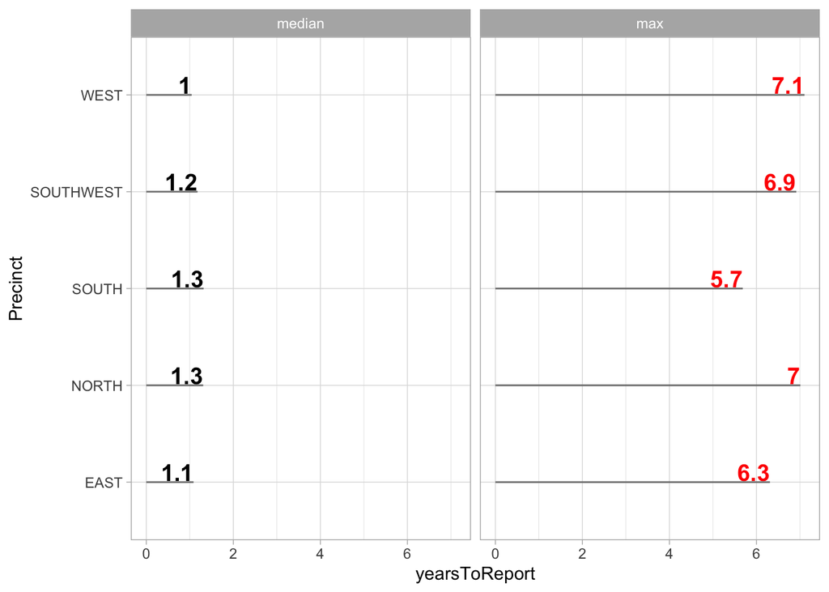

```r
bars=base_summ +
    geom_text(size = 5,hjust=1,vjust=-0.1,
                     aes(x=Precinct,
                         y=yearsToReport,
                         label=round(yearsToReport,1),
                         color=stat),
              show.legend = F, fontface='bold') +
    geom_segment(aes(y = 0,
                     x = Precinct,
                     yend = yearsToReport,
                     xend = Precinct),
                 color = "grey50") +
    scale_colour_manual(values=c("black","red"))


bars + facet_grid(~stat) + coord_flip() + theme_light()
```

There are informative plots that can be done with simpler code that will help us highlight if there are difference between these neighborhoods, but require a more solid understanding of basic stats. Let’s try the Cumulative Distribution Function (ECDF):

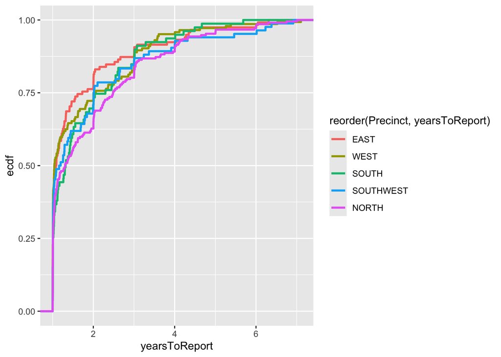

```r
base_ecdf=ggplot(crimePrecinct)

vars_ecfd=base_ecdf+
       aes(x = yearsToReport,
           color = reorder(Precinct, yearsToReport))
geom_ecfd=vars_ecfd +   stat_ecdf(linewidth = 1)

geom_ecfd
```

That was simple code! While a boxplot reduces your data to five numbers (the “summary”), it can hide the “texture” of how crimes are reported between those points. The Kruskal-Wallis and Wilcoxon tests look at the ranks of the entire distribution.

The ECDF is the visual version of these tests. If one line is consistently above another, it means that group is “stochastically smaller” (reporting faster). In your data, the NORTH line is the lowest, which visually explains why the p-value was leaning toward significance: it isn’t just one outlier; the entire “reporting behavior” in the North is shifted to the right (slower).

Let me add some details”

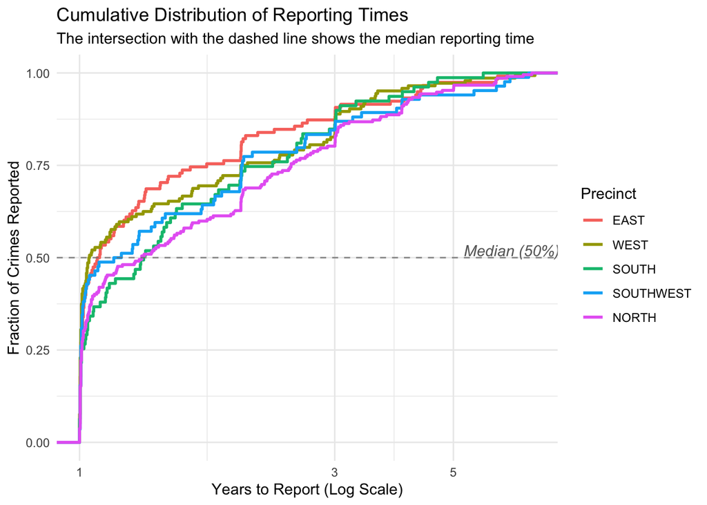

```r
geom_ecfd +
  # 1. The Median Reference Line
  geom_hline(yintercept = 0.5,
             linetype = "dashed",
             color = "grey50",
             alpha = 0.8) +
  # 2. The Text Annotation
  annotate("text",
           x = 1,              # Position at the start of the X-axis
           y = 0.52,           # Slightly above the line
           label = "Median (50%)",
           hjust = -4,          # to the right
           color = "grey40",
           fontface = "italic") +
  scale_x_log10() +
  theme_minimal() +
  labs(title = "Cumulative Distribution of Reporting Times",
       subtitle = "The intersection with the dashed line shows the median reporting time",
       y = "Fraction of Crimes Reported",
       x = "Years to Report (Log Scale)",
       color = "Precinct")
```

**How to read the ECDF Plot**

To make this visualization intuitive, follow this “Reading Guide” for the ECDF:

- **The X-Axis (Years to Report):** This represents our “deadline.” Because we used `scale_x_log10()`, we can see the detail in the early years (1–2 years), which is where most of the reporting action happens.
- **The Y-Axis (Fraction Reported):** This is the percentage of total crimes that have been reported by that specific time point. It always ranges from **0.0** (0%) to **1.0** (100%).
- **The Median (The Dashed Line):** The point where a precinct’s curve crosses the **0.5 (50%)** dashed line is its **Median Reporting Time**.
  - If the intersection is further to the **left**, the precinct reports half its crimes quickly.
  - If it’s further to the **right** (like **NORTH**), the “typical” crime takes much longer to be reported.
- **The “High Line” vs. “Low Line”:**
  - A **Higher Line** (like **EAST**) indicates a **“Fast Reporter.”** It reaches milestones (like 75%) much earlier on the X-axis than the other precincts.
  - A **Lower Line** (like **NORTH**) indicates a **“Slow Reporter.”** You have to wait much longer for it to reach the same completion rate.
- **The Vertical Jumps:** Each “step” or vertical jump in the line represents a crime being reported. A large vertical jump at a specific point means many crimes were reported at exactly that duration.

Go to table of contents.